# Document title

# 3 Analysis

## 3.1 R output

R output is typically shown in the monospace font (here an example with the `mtcars` dataset in the subfolder `data/`):

```r
# Import dataset from the data/ folder
mtcars <- read.csv("data/mtcars.csv")
summary(mtcars[,1:4])
```

```
      mpg             cyl             disp             hp
 Min.   :10.40   Min.   :4.000   Min.   : 71.1   Min.   : 52.0
 1st Qu.:15.43   1st Qu.:4.000   1st Qu.:120.8   1st Qu.: 96.5
 Median :19.20   Median :6.000   Median :196.3   Median :123.0
 Mean   :20.09   Mean   :6.188   Mean   :230.7   Mean   :146.7
 3rd Qu.:22.80   3rd Qu.:8.000   3rd Qu.:326.0   3rd Qu.:180.0
 Max.   :33.90   Max.   :8.000   Max.   :472.0   Max.   :335.0
```

## 3.2 Tables

Here is a simple table based on Markdown Syntax (Table 1).

Table 1: My Caption

| A | New | Table |
| --- | --- | --- |
| left-aligned | center-aligned | right-aligned |
| $123 | $456 | $789 |
| *italics* | strikethrough | **boldface** |

Here is a sample table output using the `knitr::kable()` function.

```r
tab <- aggregate(. ~ Species, data = iris, mean)
kable(tab)
```

Table 2: Species-specific mean lengths and widths.

| Species | Sepal.Length | Sepal.Width | Petal.Length | Petal.Width |
| --- | --- | --- | --- | --- |
| setosa | 5.006 | 3.428 | 1.462 | 0.246 |
| versicolor | 5.936 | 2.770 | 4.260 | 1.326 |
| virginica | 6.588 | 2.974 | 5.552 | 2.026 |

## 3.3 Figures

A base graphics histogram (Fig. 4).

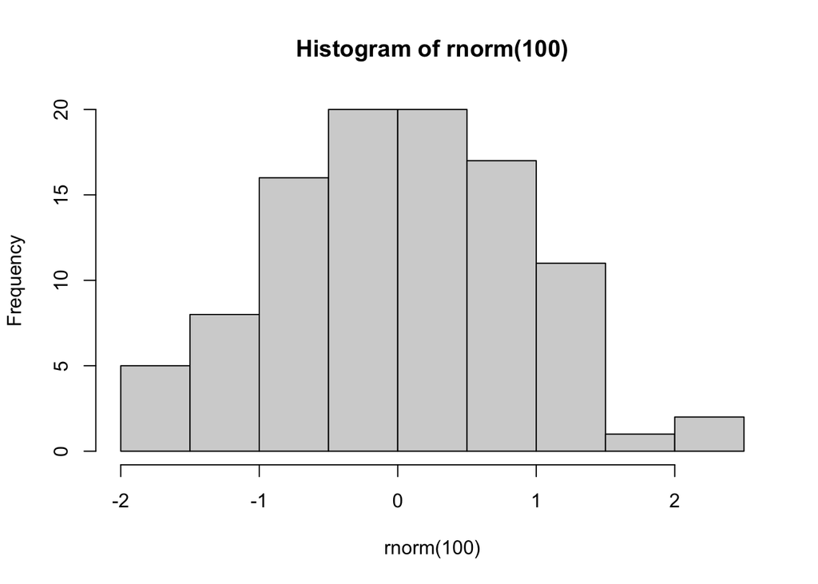

Figure 4: A Histogram made with the basic graphics package

```r
hist(rnorm(100))
```

Here for comparison a boxplot with a different image height (Fig. 5).

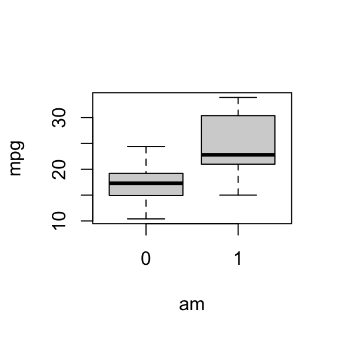

Figure 5: Fuel differences between transmission types (0 = automatic, 1 = manual).

```r
boxplot(mpg ~ am, mtcars)
```

## 3.4 Tabbed sections

You can create a tabset via a markdown div with the class name *panel-tabset*. Each top-level heading within the div creates a new tab as shown below:

**First tab**

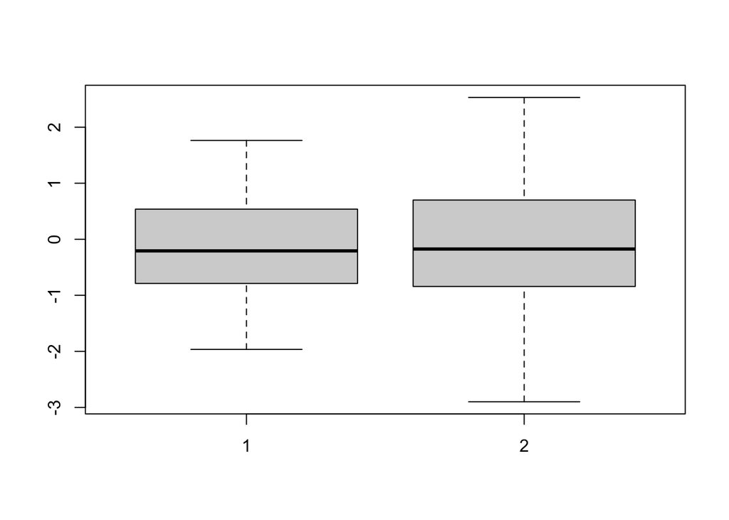

Figure 6: Boxplot made with the basic graphics package

```r
boxplot(rnorm(100), rnorm(100))
```

**Second tab**

## 3.5 Interactive figures with plotly

If the package ‘plotly’ is installed, the following code block will be executed:

```r
p <- plotly::plot_ly(data = mtcars, x = ~mpg, y = ~wt, color = ~cyl)
plotly::add_markers(p)
```

[interactive chart not shown]

Figure 7: This is the interactive htmlwidget ‘plotly’

## 3.6 Diagrams

Quarto has native support for embedding *Mermaid* and *Graphviz* diagrams. This enables you to create flowcharts, sequence diagrams, state diagrams, Gantt charts, and more using a plain text syntax inspired by markdown.

### 3.6.1 Mermaid

Mermaid is a Javascript based diagramming and charting tool that uses Markdown-inspired text definitions and a renderer to create and modify complex diagrams (see Fig. 8).

```
flowchart LR
  A[Hard edge] --> B(Round edge)
  B --> C{Decision}
  C --> D[Result one]
  C --> E[Result two]
  style C fill:#f9f,stroke:#333,stroke-width:4px
  style E fill:#bbf,stroke:#f66,stroke-width:2px,color:#fff,stroke-dasharray: 5 5
```

[output not shown]

Figure 8: Simple flowchart based on the JS-tool Mermaid.

**Note**

Cell level options are here indicated with `%%|` instead of `#|`!

```
sequenceDiagram
  participant Alice
  participant Bob
  Alice->>John: Hello John, how are you?
  loop Healthcheck
    John->>John: Fight against hypochondria
  end
  Note right of John: Rational thoughts <br/>prevail!
  John-->>Alice: Great!
  John->>Bob: How about you?
  Bob-->>John: Jolly good!
```

[output not shown]

Figure 9: A sequence diagram based on Mermaid.

Useful links:

- https://mermaid-js.github.io/mermaid/#/
- https://mermaid.live

### 3.6.2 Graphviz

The [Graphviz](https://graphviz.org/) layout programs take descriptions of graphs in a simple text language and make diagrams in useful formats. Graphviz has many useful features for concrete diagrams, such as options for colors, fonts, tabular node layouts, line styles, hyperlinks, and custom shapes (see Fig. 10).

```dot
graph G {
  layout=neato
  run -- intr;
  intr -- runbl;
  runbl -- run;
  run -- kernel;
  kernel -- zombie;
  kernel -- sleep;
  kernel -- runmem;
  sleep -- swap;
  swap -- runswap;
  runswap -- new;
  runswap -- runmem;
  new -- runmem;
  sleep -- runmem;
}
```

[figure not shown]

Figure 10: An example for a diagram made with Graphviz.

**Note**

Cell level options are here indicated with `//|`!

# 4 Footnotes

Here is a footnote reference[^1], and another[^2].

# 5 Adding citations and bibliography

Link a `.bib` document via the YAML header, and the bibliography will be printed at the end. The default bibliography style is provided in the `sage-harvard.csl` file (do not delete), which adopts the [SAGE Harvard](https://uk.sagepub.com/sites/default/files/sage_harvard_reference_style_0.pdf) reference style.

References can be cited directly within the document using the Quarto equivalent of the citation system `[@key]`, where key is the citation key in the first line of the entry in the .bib file. Example: (Taylor and Green, 1937). To cite multiple entries, separate the keys by semicolons (e.g., (Kamm, 2000; Knupp, 1999)). You can also write in-text citations, as follows: Taylor and Green (1937) say this and that.

There is also the package citr which I highly recommend: *citr* provides functions and an RStudio add-in to search a BibTeX-file to create and insert formatted Markdown citations into the current document. If you are using the reference manager [Zotero](https://www.zotero.org/) the add-in can access your reference database directly.

## 5.1 Software

If you want to include a paragraph on the software used, here is some example text/code to get the current R and package versions. The code to generate a bibliography file including all package references has been already added at the beginning of this script (code chunk ‘generate-package-refs’).

All analyses were performed using the statistical software R (version 4.5.2) (R Core Team, 2025). This report, including tables and figures, was generated using the R packages ‘rmarkdown’ (version 2.30) (Allaire et al., 2025), ‘UHHformats’ (version 1.1.0.9000) (Otto, 2026), and ‘knitr’ (version 1.51) (Xie, 2025).

# 6 References

Allaire J, Xie Y, Dervieux C, et al. (2025) *Rmarkdown: Dynamic Documents for r*. Available at: https://github.com/rstudio/rmarkdown.

Kamm J (2000) *Evaluation of the Sedov-von Neumann-Taylor blast wave solution*. Technical Report LA-UR-00-6055. Los Alamos National Laboratory.

Knupp P (1999) Winslow smoothing on two-dimensional unstructured meshes. *Eng Comput* 15: 263–268.

Otto S (2026) *UHHformats: Templates for HTML and PDF/LaTeX Output Formats Designed for the UHH*. Available at: https://github.com/uham-bio/UHHformats.

R Core Team (2025) *R: A Language and Environment for Statistical Computing*. Vienna, Austria: R Foundation for Statistical Computing. Available at: https://www.R-project.org/.

Taylor G and Green A (1937) Mechanism of the production of small eddies from large ones. *P Roy Soc Lond A Mat* 158(895): 499–521.

Xie Y (2025) *Knitr: A General-Purpose Package for Dynamic Report Generation in r*. Available at: https://yihui.org/knitr/.

## Footnotes

[^1]: Here is the footnote.
[^2]: Here’s one with multiple blocks.

    Subsequent paragraphs are indented to show that they belong to the previous footnote.

    ```
    { some.code }
    ```

    The whole paragraph can be indented, or just the first line. In this way, multi-paragraph footnotes work like multi-paragraph list items.